# Demographic Impact on Economic Growth

Analyzing the Impact of Demographic Factors, Including Population Growth, Age Structure, and Education, on Global Economic Growth Between 2013 and 2023

Authors

Alua Aldaniyaz

Asmae Nakib

Oleksii Terletskyi

Abstract

This study examined the relationship between demographic factors and GDP growth from 2013 to 2023 using panel regression models and global economic data. Population growth emerged as a statistically significant driver of economic expansion in contexts with limited alternative growth factors (coefficient: 4.51, p = 0.004), while its effect diminished in more diversified economies. Other variables, including age structure and education levels, demonstrated limited explanatory power, with statistically insignificant results across all models. Low R² values (ranging from -0.25 to 0.10) indicate that demographic factors alone are insufficient to explain GDP variability, underscoring the importance of additional economic and institutional drivers. Refinements in the analysis improved model reliability, revealing the importance of robust data preparation and methodological rigor. The findings provide a nuanced understanding of the demographic-economic relationship, highlighting population growth as a key variable in less complex economies while suggesting further exploration of structural factors in advanced contexts.

# 1 INTRODUCTION

**Background**  
Demographic factors, such as population growth, age structure, and education levels, play a pivotal role in shaping economic development. Over the past decade (2013–2023), global economies have faced challenges ranging from demographic shifts to economic disruptions caused by the COVID-19 pandemic. Understanding how these demographic trends influence economic outcomes is essential for policymakers and researchers striving to foster sustainable growth.

**Research Questions**  
This study aims to answer the following primary research question:

**How do demographic factors influence economic growth between 2013 and 2023?**

To address this overarching question, three specific hypotheses are explored:

1. **Population Growth:** Does population growth drive economic growth?
2. **Age Structure:** How does age structure impact economic growth, and is an aging population negatively affecting it?
3. **Education Levels:** Does a more educated population correlate with higher economic growth?

**Significance of the Study**  
By examining these questions, this research seeks to uncover the intricate relationships between demographic trends and economic outcomes. The findings aim to provide insights into the long-term economic implications of demographic changes and inform evidence-based policy decisions.

# 2 DATA

**Data and Sources**  
To address the research questions, this study utilizes data from the World Bank’s World Development Indicators (WDI), a comprehensive and widely recognized dataset. The WDI dataset offers annual, standardized measurements of demographic and economic variables, including population metrics, education levels, and GDP growth, across multiple countries. Data collection integrates inputs from national statistical offices, international organizations, and independent surveys, ensuring high reliability and accuracy.

The dataset spans a decade (2013–2023), allowing for a robust analysis of global trends. Key variables include:

**Population Growth Rate:** Annual percentage change in population size.

**Age Groups:** Proportions of populations aged 0–14, 15–64 (working age), and 65+.

**Education Metrics:** Enrollment rates and levels of educational attainment.

**GDP Growth:** Annual percentage growth in real GDP.

**Time frame:** The period from 2013 to 2023 provides a decade of data, offering a sufficient time frame to observe meaningful demographic and economic trends.

**Countries:** The report will focus on all countries available in the dataset, to capture global trends.

```r
# Install and load necessary libraries
#| label: packages-data-functions
#| message: false
suppressWarnings(suppressMessages({
  packages <- c("WDI", "plm", "dplyr", "ggplot2", "knitr", "kableExtra", "corrplot", "gridExtra", "broom", "lmtest")
    # Check and install missing packages
  for (pkg in packages) {
    if (!require(pkg, character.only = TRUE, quietly = TRUE)) {
      install.packages(pkg, quiet = TRUE)
    }
  }
  # Load packages without messages
  invisible(lapply(packages, library, character.only = TRUE))
}))
# Define the relative file path
data_file <- "data.csv"
# Check if 'data.csv' exists
if (file.exists(data_file)) {
  # Load data from the existing file
  wdi_data <- read.csv(data_file)
} else {
  # Fetch data from the World Development Indicators (WDI) database
  start_year <- 2013
  end_year <- 2023
  wdi_data <- WDI(indicator = c(
    "SP.POP.TOTL",                 # Total Population
    "NY.GDP.MKTP.KD",              # GDP (constant 2015 USD)
    "SP.POP.GROW",                 # Population Growth (%)
    "NY.GDP.MKTP.KD.ZG",           # GDP Growth (%)
    "SP.POP.0014.TO.ZS",           # Age 0-14 (% of total population)
    "SP.POP.1564.TO.ZS",           # Age 15-64 (% of total population)
    "SP.POP.65UP.TO.ZS",           # Age 65 and above (% of total population)
    "SE.PRM.ENRR",                 # Primary School Enrollment (%)
    "SE.SEC.ENRR",                 # Secondary School Enrollment (%)
    "SE.TER.ENRR",                 # Gross Enrollment Ratio (%)
    "SE.PRM.CUAT.ZS"               # Educational attainment (%)
  ), start = start_year, end = end_year, extra = TRUE)
  # Clean and rename columns
  wdi_data <- wdi_data %>%
    select(
      country, year, SP.POP.GROW, NY.GDP.MKTP.KD.ZG, SP.POP.0014.TO.ZS,
      SP.POP.1564.TO.ZS, SP.POP.65UP.TO.ZS, SE.PRM.ENRR, SE.SEC.ENRR,
      SE.PRM.CUAT.ZS, income, SP.POP.TOTL, NY.GDP.MKTP.KD
    ) %>%
    rename(
      pop_growth = SP.POP.GROW,
      gdp_growth = NY.GDP.MKTP.KD.ZG,
      age_0_14 = SP.POP.0014.TO.ZS,
      age_15_64 = SP.POP.1564.TO.ZS,
      age_65_plus = SP.POP.65UP.TO.ZS,
      primary_enrollment = SE.PRM.ENRR,
      secondary_enrollment = SE.SEC.ENRR,
      educational_attainment = SE.PRM.CUAT.ZS,
      income_level = income,
      pop_total = SP.POP.TOTL,
      gdp_real = NY.GDP.MKTP.KD
    ) %>%
    filter(
      !is.na(gdp_growth), !is.na(pop_growth),
      !is.na(age_0_14), !is.na(age_15_64),
      !is.na(age_65_plus), !is.na(educational_attainment),
      !is.na(income_level), !is.na(pop_total),
      !is.na(gdp_real)
    )
  # Save the cleaned data to a CSV file
  write.csv(wdi_data, data_file, row.names = FALSE)
}
# Create the data frame for the table
data <- data.frame(
  "Variable Name" = c(
    "Population Growth", "GDP Growth", "Age 0–14", "Age 15–64", "Age 65+",
    "Primary Enrollment", "Secondary Enrollment", "Educational Attainment",
    "Income Level", "Total Population", "Real GDP"
  ),
  "WDI Code" = c(
    "SP.POP.GROW", "NY.GDP.MKTP.KD.ZG", "SP.POP.0014.TO.ZS", "SP.POP.1564.TO.ZS",
    "SP.POP.65UP.TO.ZS", "SE.PRM.ENRR", "SE.SEC.ENRR", "SE.PRM.CUAT.ZS",
    "income", "SP.POP.TOTL", "NY.GDP.MKTP.KD"
  ),
  "Significance to the Study" = c(
    "Measures annual population growth, a key factor in assessing demographic changes.",
    "Captures annual economic growth, providing insight into the relationship with demographics.",
    "Represents the percentage of the population aged 0–14, crucial for analyzing age dependency.",
    "Represents the working-age population, which impacts economic productivity and growth.",
    "Indicates the aging population, helping to assess its economic implications.",
    "Tracks primary education enrollment, linked to foundational human capital development.",
    "Tracks secondary education enrollment, reflecting skill development for economic growth.",
    "Measures the percentage of adults completing primary education, showing overall education levels.",
    "Indicates the income category of countries, providing context for economic and demographic analysis.",
    "Measures the total population, essential for understanding demographic scale and trends.",
    "Reflects the real GDP, offering a measure of economic output adjusted for inflation."
  )
)
# Create and display the styled table
kable(data) %>%
  kable_styling(full_width = FALSE, position = "center", bootstrap_options = c("striped", "hover", "condensed")) %>%
  column_spec(1, width = "15em", bold = TRUE, background = "#f9f9f9", extra_css = "vertical-align: middle; text-align: center;") %>%
  column_spec(2, width = "15em", extra_css = "vertical-align: middle; text-align: center;") %>%
  column_spec(3, width = "30em", italic = TRUE)
```

| Variable.Name | WDI.Code | Significance.to.the.Study |
| --- | --- | --- |
| Population Growth | SP.POP.GROW | Measures annual population growth, a key factor in assessing demographic changes. |
| GDP Growth | NY.GDP.MKTP.KD.ZG | Captures annual economic growth, providing insight into the relationship with demographics. |
| Age 0–14 | SP.POP.0014.TO.ZS | Represents the percentage of the population aged 0–14, crucial for analyzing age dependency. |
| Age 15–64 | SP.POP.1564.TO.ZS | Represents the working-age population, which impacts economic productivity and growth. |
| Age 65+ | SP.POP.65UP.TO.ZS | Indicates the aging population, helping to assess its economic implications. |
| Primary Enrollment | SE.PRM.ENRR | Tracks primary education enrollment, linked to foundational human capital development. |
| Secondary Enrollment | SE.SEC.ENRR | Tracks secondary education enrollment, reflecting skill development for economic growth. |
| Educational Attainment | SE.PRM.CUAT.ZS | Measures the percentage of adults completing primary education, showing overall education levels. |
| Income Level | income | Indicates the income category of countries, providing context for economic and demographic analysis. |
| Total Population | SP.POP.TOTL | Measures the total population, essential for understanding demographic scale and trends. |
| Real GDP | NY.GDP.MKTP.KD | Reflects the real GDP, offering a measure of economic output adjusted for inflation. |

This combination of demographic and economic indicators enables a comprehensive exploration of the interplay between demographic shifts and economic performance.

# 3 EXPLORATORY DATA ANALYSIS

```r
# Perform Exploratory Data Analysis (EDA)
# Filter data for specific years
data_2015 <- wdi_data %>% filter(year == 2015)
data_2018 <- wdi_data %>% filter(year == 2018)
data_2022 <- wdi_data %>% filter(year == 2022)
# Calculate summary statistics for selected years
eda_summary <- list(
  "2015" = summary(data_2015),
  "2018" = summary(data_2018),
  "2022" = summary(data_2022)
)
# Prepare filtered summary statistics for a single year (2015)
key_metrics <- data_2015 %>%
  summarise(
    Min_GDP_Growth = min(gdp_growth, na.rm = TRUE),
    Median_GDP_Growth = median(gdp_growth, na.rm = TRUE),
    Mean_GDP_Growth = mean(gdp_growth, na.rm = TRUE),
    Max_GDP_Growth = max(gdp_growth, na.rm = TRUE),
    Min_Pop_Growth = min(pop_growth, na.rm = TRUE),
    Median_Pop_Growth = median(pop_growth, na.rm = TRUE),
    Mean_Pop_Growth = mean(pop_growth, na.rm = TRUE),
    Max_Pop_Growth = max(pop_growth, na.rm = TRUE)
  )
# Convert to a data frame for better display
key_metrics_table <- as.data.frame(t(key_metrics))
colnames(key_metrics_table) <- c("Value")
# Create a styled table
kable(key_metrics_table, caption = "Key Metrics for the Year 2015") %>%
  kable_styling(full_width = FALSE, position = "center", bootstrap_options = c("striped", "hover", "condensed")) %>%
  column_spec(1, width = "25em", bold = TRUE) %>%
  column_spec(2, width = "10em", italic = TRUE)
```

Key Metrics for the Year 2015

|  | Value |
| --- | --- |
| Min_GDP_Growth | -3.545763 |
| Median_GDP_Growth | 2.945550 |
| Mean_GDP_Growth | 3.316186 |
| Max_GDP_Growth | 24.615570 |
| Min_Pop_Growth | -2.142484 |
| Median_Pop_Growth | 1.120993 |
| Mean_Pop_Growth | 1.215072 |
| Max_Pop_Growth | 8.581733 |

Similar calculations have been performed for other years (2018 and 2022), but they are omitted here to maintain report brevity and readability.

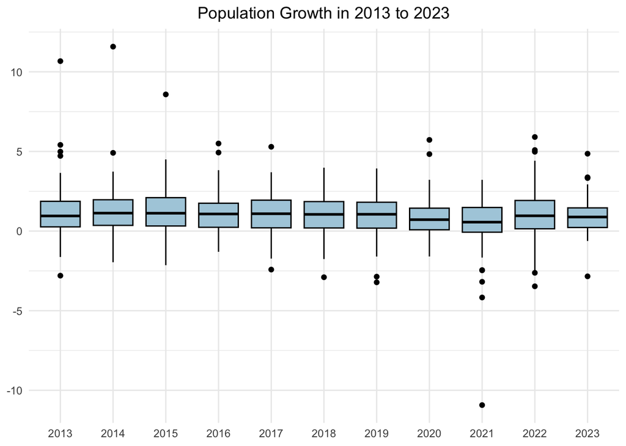

```r
# Boxplots to compare population growth and GDP growth
# Population Growth
ggplot(wdi_data, aes(x = factor(year), y = pop_growth)) +
  geom_boxplot(fill = "#adcede", color = "black") +
  labs(title = "Population Growth in 2013 to 2023") +
  theme_minimal() +
  theme(
    legend.position = "none",                # Remove legend
    plot.title = element_text(hjust = 0.5), # Center align title
    axis.title.x = element_blank(),          # Remove x-axis title
    axis.title.y = element_blank()           # Remove y-axis title
  )
```

From 2013 to 2023, the global population growth rate exhibited a steady decline, beginning at 1.24% in 2013 and reaching 0.98% by 2020. This downward trend was further accelerated by the COVID-19 pandemic, which significantly impacted global population dynamics, reducing the growth rate to 0.83% in 2021. As the effects of the pandemic began to subside, a modest recovery was observed, with the growth rate rebounding slightly to 0.88% in 2023. This trajectory underscores the pandemic’s immediate disruptive influence on demographic patterns, followed by a gradual stabilization in subsequent years.

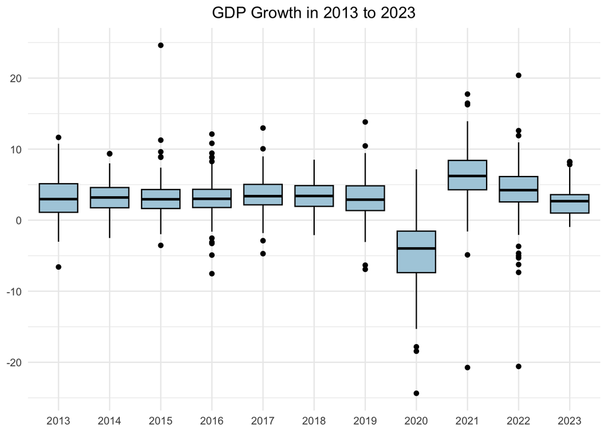

```r
# GDP Growth
ggplot(wdi_data, aes(x = factor(year), y = gdp_growth)) +
  geom_boxplot(fill = "#adcede", color = "black", outlier.color = "black") +
  labs(title = "GDP Growth in 2013 to 2023") +
  theme_minimal() +
  theme(
    legend.position = "none",                 # Remove legend
    plot.title = element_text(hjust = 0.5),  # Center-align title
    axis.title = element_blank()             # Remove axis titles
  )
```

Over the past decade, global GDP growth demonstrated variability, generally oscillating between 2% and 3%. Starting at 2.87% in 2013, it peaked at 2.94% in 2019. However, the onset of the COVID-19 pandemic in 2020 triggered a severe contraction, with GDP growth plunging to -2.93% as lockdown measures and halted economic activity disrupted global markets. A swift rebound followed in 2021, with GDP growth surging to 6.26%, marking a period of recovery. Subsequently, growth stabilized within the 2%-3% range, reflecting the economic adjustments and lingering challenges of the post-pandemic environment.

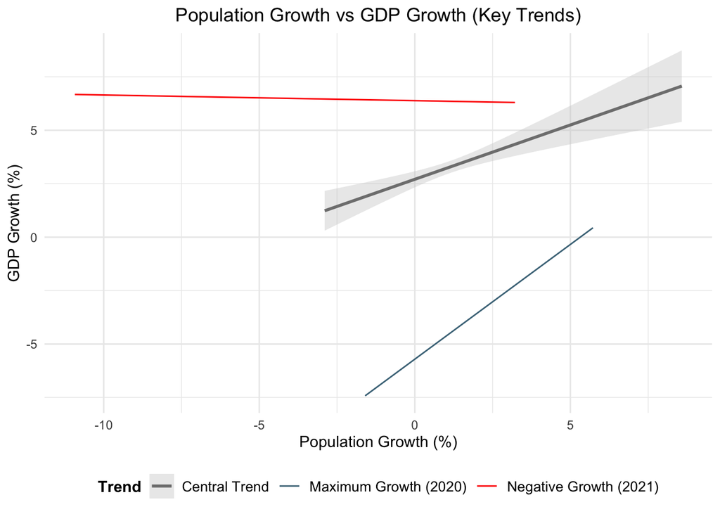

```r
# All regressions for 10 years for all countries
# Perform calculations
regression_slopes <- wdi_data %>%
  group_by(year) %>%
  summarize(
    slope = coef(lm(gdp_growth ~ pop_growth))[2] # Extract slope (coefficient of pop_growth)
  )
regression_slopes <- regression_slopes %>%
  mutate(
    classification = ifelse(slope > 0, "positive", "negative")
  )
# Merge classifications back into the dataset
wdi_data_classified <- wdi_data %>%
  inner_join(regression_slopes, by = "year")
# Filter for three key trends: overall (central), maximum growth, and negative growth
central_trend <- wdi_data_classified %>%
  filter(year %in% c(2015, 2016, 2018)) # Example of years for central trend
max_growth_trend <- wdi_data_classified %>%
  filter(year == 2020) # Example of maximum growth
negative_growth_trend <- wdi_data_classified %>%
  filter(year == 2021) # Example of negative growth
# Create the plot with a custom legend
ggplot() +
  # Central trend
  geom_smooth(data = central_trend, aes(x = pop_growth, y = gdp_growth, color = "Central Trend"),
              method = "lm", se = TRUE, formula = y ~ x, fill = "gray80", linetype = "solid") +
  # Maximum growth trend
  geom_smooth(data = max_growth_trend, aes(x = pop_growth, y = gdp_growth, color = "Maximum Growth (2020)"),
              method = "lm", se = FALSE, formula = y ~ x, linewidth = 0.5, linetype = "solid") +
  # Negative growth trend
  geom_smooth(data = negative_growth_trend, aes(x = pop_growth, y = gdp_growth, color = "Negative Growth (2021)"),
              method = "lm", se = FALSE, formula = y ~ x, linewidth = 0.5, linetype = "solid") +
  labs(
    title = "Population Growth vs GDP Growth (Key Trends)",
    x = "Population Growth (%)",
    y = "GDP Growth (%)",
    color = "Trend"
  ) +
  scale_color_manual(
    values = c("Central Trend" = "gray50", "Maximum Growth (2020)" = "#497387", "Negative Growth (2021)" = "red")
  ) +
  theme_minimal() +
  theme(
    legend.position = "bottom",               # Move legend to the bottom
    plot.title = element_text(hjust = 0.5),  # Center-align title
    legend.title = element_text(face = "bold"), # Bold legend title
    legend.text = element_text(size = 10)    # Adjust legend text size
  )
```

Positive regression coefficients observed across most years indicate a general positive relationship between population and GDP growth. Higher population growth often correlates with an expanding labor force, increased demand for goods and services, and stimulated economic production. Investments to support a growing population further boost economic activity.

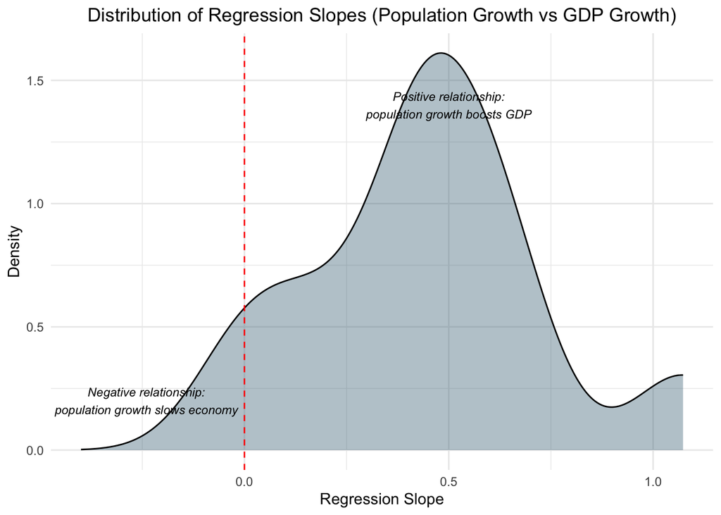

```r
# Calculate regression slopes by year
regression_slopes <- wdi_data %>%
  group_by(year) %>%
  summarize(
    slope = coef(lm(gdp_growth ~ pop_growth))[2] # Extract slope (coefficient of pop_growth)
  )
# Create density plot with annotations
ggplot(regression_slopes, aes(x = slope)) +
  geom_density(fill = "#497387", alpha = 0.4) +
  geom_vline(xintercept = 0, linetype = "dashed", color = "red") +
  annotate("text", x = 0.5, y = 1.4, label = "Positive relationship:\npopulation growth boosts GDP", size = 3, fontface = "italic", color = "black") +
  annotate("text", x = -0.24, y = 0.2, label = "Negative relationship:\npopulation growth slows economy", size = 3, fontface = "italic", color = "black") +
  labs(
    title = "Distribution of Regression Slopes (Population Growth vs GDP Growth)",
    x = "Regression Slope",
    y = "Density"
  ) +
  xlim(-0.4, NA) +
  theme_minimal() +
  theme(
    plot.title = element_text(hjust = 0.5)
  )
```

```r
# Calculate mean and standard deviation for population growth and GDP growth
stats <- wdi_data %>%
  summarize(
    mean_pop_growth = mean(pop_growth, na.rm = TRUE),
    sd_pop_growth = sd(pop_growth, na.rm = TRUE),
    mean_gdp_growth = mean(gdp_growth, na.rm = TRUE),
    sd_gdp_growth = sd(gdp_growth, na.rm = TRUE)
  )
# Define the ranges for 1, 2, and 3 sigma
sigma_ranges <- data.frame(
  Metric = c("Population Growth", "GDP Growth"),
  `1 Sigma` = c(
    paste0(round(stats$mean_pop_growth - stats$sd_pop_growth, 2), " to ",
           round(stats$mean_pop_growth + stats$sd_pop_growth, 2)),
    paste0(round(stats$mean_gdp_growth - stats$sd_gdp_growth, 2), " to ",
           round(stats$mean_gdp_growth + stats$sd_gdp_growth, 2))
  ),
  `2 Sigma` = c(
    paste0(round(stats$mean_pop_growth - 2 * stats$sd_pop_growth, 2), " to ",
           round(stats$mean_pop_growth + 2 * stats$sd_pop_growth, 2)),
    paste0(round(stats$mean_gdp_growth - 2 * stats$sd_gdp_growth, 2), " to ",
           round(stats$mean_gdp_growth + 2 * stats$sd_gdp_growth, 2))
  ),
  `3 Sigma` = c(
    paste0(round(stats$mean_pop_growth - 3 * stats$sd_pop_growth, 2), " to ",
           round(stats$mean_pop_growth + 3 * stats$sd_pop_growth, 2)),
    paste0(round(stats$mean_gdp_growth - 3 * stats$sd_gdp_growth, 2), " to ",
           round(stats$mean_gdp_growth + 3 * stats$sd_gdp_growth, 2))
  )
)
# Load necessary libraries for table output
library(knitr)
library(kableExtra)
# Display the sigma ranges table
kable(sigma_ranges, caption = "Ranges for 1, 2, and 3 Sigma for Population and GDP Growth") %>%
  kable_styling(full_width = FALSE, position = "center", bootstrap_options = c("striped", "hover", "condensed"))
```

Ranges for 1, 2, and 3 Sigma for Population and GDP Growth

| Metric | X1.Sigma | X2.Sigma | X3.Sigma |
| --- | --- | --- | --- |
| Population Growth | -0.38 to 2.43 | -1.78 to 3.83 | -3.18 to 5.23 |
| GDP Growth | -1.32 to 7.14 | -5.56 to 11.37 | -9.79 to 15.6 |

```r
# Load necessary libraries
suppressWarnings(library(tidyr))
suppressWarnings(library(knitr))
suppressWarnings(library(kableExtra))
# Define variables for correlation analysis
variables <- c("pop_growth", "age_65_plus", "educational_attainment")
# Calculate correlations
correlations <- wdi_data %>%
  group_by(year) %>%
  summarize(
    across(all_of(variables), ~ cor(.x, gdp_growth, use = "complete.obs"), .names = "cor_{.col}")
  ) %>%
  pivot_longer(-year, names_to = "variable", values_to = "correlation")

# Display first 10 rows of the correlations table
correlations %>%
  head(10) %>%
  kable(caption = "Correlations of Variables with GDP Growth (First 10 Rows)") %>%
  kable_styling(full_width = FALSE, bootstrap_options = c("striped", "hover", "condensed")) %>%
  column_spec(1, width = "5em") %>%
  column_spec(2, width = "10em") %>%
  column_spec(3, width = "10em")
```

Correlations of Variables with GDP Growth (First 10 Rows)

| year | variable | correlation |
| --- | --- | --- |
| 2013 | cor_pop_growth | 0.3517966 |
| 2013 | cor_age_65_plus | -0.5744705 |
| 2013 | cor_educational_attainment | -0.3750770 |
| 2014 | cor_pop_growth | 0.2841994 |
| 2014 | cor_age_65_plus | -0.3851039 |
| 2014 | cor_educational_attainment | -0.3383917 |
| 2015 | cor_pop_growth | 0.1993899 |
| 2015 | cor_age_65_plus | -0.1856340 |
| 2015 | cor_educational_attainment | -0.1729920 |
| 2016 | cor_pop_growth | 0.2647237 |

This table presents the correlation between key variables (e.g., population growth, percentage of people aged 65 and older, and educational attainment) and GDP growth across different years. For instance, in 2013, population growth had a positive correlation with GDP growth (0.352), indicating a supportive relationship, while the share of people over 65 showed a negative correlation (-0.574), suggesting an opposing effect. This analysis highlights how demographic and educational factors influenced economic growth over time, helping to identify which variables played significant roles in different periods.

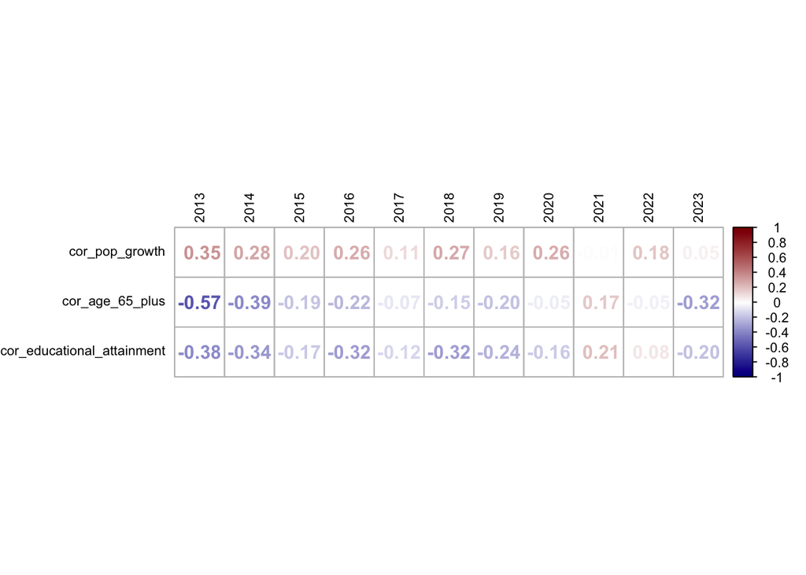

```r
# load the necessary package
suppressWarnings(library(corrplot))

# Prepare the correlation matrix for year and variables
cor_matrix <- correlations %>%
  pivot_wider(names_from = year, values_from = correlation) %>%
  select(-variable) %>%
  as.matrix()

# Assign row names as variables
rownames(cor_matrix) <- unique(correlations$variable)

# Plot the correlation matrix with specified parameters
corrplot(
  cor_matrix,
  method = "number",           # Use numbers instead of circles
  tl.cex = 0.7,                # Text size for labels
  tl.col = "black",            # Label color
  tl.srt = 90,                 # Rotate top labels for better readability
  cl.cex = 0.7,                # Color legend text size
  col = colorRampPalette(c("darkblue", "white", "darkred"))(200)  # Swap colors
)
```

**Population Growth and GDP Growth**  
Population growth generally shows a positive but moderate correlation with GDP growth, typically under 0.5, indicating that while population expansion supports economic growth, its influence is limited. In 2021, the correlation turned negative, reflecting the economic disruptions caused by the COVID-19 pandemic, such as lockdowns and decreased productivity. This anomaly highlights the pandemic’s overriding impact on economic dynamics, despite continued population growth.

**Educational Attainment and GDP Growth**  
Educational attainment generally shows a moderately negative correlation with GDP growth, typically above -0.5, suggesting that initial investments in education may slow economic growth due to associated costs. However, these short-term effects are often offset by long-term gains in human capital, productivity, and economic expansion. In 2021 and 2022, this relationship turned slightly positive, likely reflecting the increased demand for skilled labor driven by the adoption of digital technologies and remote work during the pandemic.

**Age Structure and GDP Growth**  
The negative correlation between age structure and GDP growth indicates that an aging population is generally linked to slower economic expansion. This is often due to a shrinking labor force and potentially lower overall productivity. In 2021, however, the correlation became positive, possibly reflecting increased healthcare spending during the pandemic or a temporary rise in labor force participation among older individuals driven by shifting economic conditions.

# 4 COMBINED CROSS-SECTIONAL ANALYSIS

We will conduct a cross-sectional analysis for the years 2015, 2018, and 2022, sequentially adding variables to each year. We will compare these findings with those from a panel data model to assess the consistency and robustness of our results.

## 4.1 GDP Growth and Population, Aging and Educatioal 2015-2018-2022

### 4.1.1 Population Growth and GDP Growth 2015-2018-2022

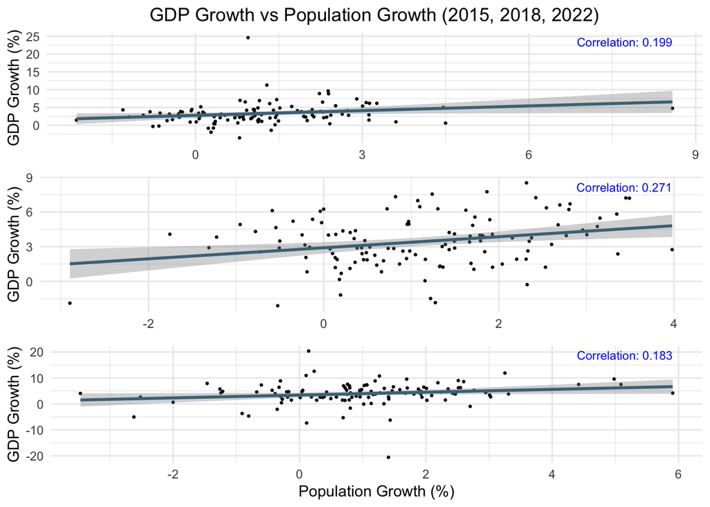

```r
library(ggplot2)
library(dplyr)
library(gridExtra)

# Filter data for years 2015, 2018, and 2022
data_2015 <- wdi_data %>% filter(year == 2015)
data_2018 <- wdi_data %>% filter(year == 2018)
data_2022 <- wdi_data %>% filter(year == 2022)

# Calculate correlations
cor_2015_pop <- cor(data_2015$pop_growth, data_2015$gdp_growth, use = "complete.obs")
cor_2018_pop <- cor(data_2018$pop_growth, data_2018$gdp_growth, use = "complete.obs")
cor_2022_pop <- cor(data_2022$pop_growth, data_2022$gdp_growth, use = "complete.obs")

# Scatter plot for 2015
plot_2015 <- ggplot(data_2015, aes(x = pop_growth, y = gdp_growth)) +
  geom_point(size = 0.5, color = "black") +
  geom_smooth(method = "lm", se = TRUE, formula = y ~ x, color = "#497387") +
  annotate("text", x = max(data_2015$pop_growth, na.rm = TRUE), y = max(data_2015$gdp_growth, na.rm = TRUE),
           label = paste0("Correlation: ", round(cor_2015_pop, 3)), hjust = 1, vjust = 1, size = 3, color = "blue") +
  labs(
    title = "GDP Growth vs Population Growth (2015, 2018, 2022)",
    x = NULL,
    y = "GDP Growth (%)"
  ) +
  theme_minimal() +
  theme(plot.title = element_text(hjust = 0.5))
# Scatter plot for 2018
plot_2018 <- ggplot(data_2018, aes(x = pop_growth, y = gdp_growth)) +
  geom_point(size = 0.5, color = "black") +
  geom_smooth(method = "lm", se = TRUE, formula = y ~ x, color = "#497387") +
  annotate("text", x = max(data_2018$pop_growth, na.rm = TRUE), y = max(data_2018$gdp_growth, na.rm = TRUE),
           label = paste0("Correlation: ", round(cor_2018_pop, 3)), hjust = 1, vjust = 1, size = 3, color = "blue") +
  labs(
    title = NULL,
    x = NULL,
    y = "GDP Growth (%)"
  ) +
  theme_minimal()
# Scatter plot for 2022
plot_2022 <- ggplot(data_2022, aes(x = pop_growth, y = gdp_growth)) +
  geom_point(size = 0.5, color = "black") +
  geom_smooth(method = "lm", se = TRUE, formula = y ~ x, color = "#497387") +
  annotate("text", x = max(data_2022$pop_growth, na.rm = TRUE), y = max(data_2022$gdp_growth, na.rm = TRUE),
           label = paste0("Correlation: ", round(cor_2022_pop, 3)), hjust = 1, vjust = 1, size = 3, color = "blue") +
  labs(
    title = NULL,
    x = "Population Growth (%)",
    y = "GDP Growth (%)"
  ) +
  theme_minimal()
# Arrange the plots in a single block
grid.arrange(plot_2015, plot_2018, plot_2022, nrow = 3)
```

In 2022, 1% population growth is associated with 0.5479% increase in GDP and this relationship is statistically significant (p-value = 0.0481) with a correlation coefficient (18.3%), indicating a weak but positive effect of demography on economic growth.

### 4.1.2 Aging Population and GDP Growth 2015-2018-2022

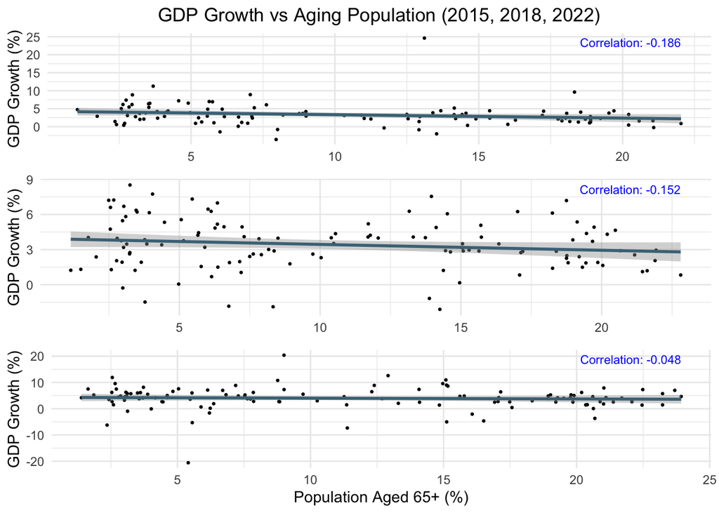

```r
library(ggplot2)
library(dplyr)
library(gridExtra)
# Filter data for years 2015, 2018, and 2022
data_2015 <- wdi_data %>% filter(year == 2015)
data_2018 <- wdi_data %>% filter(year == 2018)
data_2022 <- wdi_data %>% filter(year == 2022)
# Calculate correlations for Aging Population and GDP Growth
cor_2015_age <- cor(data_2015$age_65_plus, data_2015$gdp_growth, use = "complete.obs")
cor_2018_age <- cor(data_2018$age_65_plus, data_2018$gdp_growth, use = "complete.obs")
cor_2022_age <- cor(data_2022$age_65_plus, data_2022$gdp_growth, use = "complete.obs")
# Scatter plot for 2015
plot_2015 <- ggplot(data_2015, aes(x = age_65_plus, y = gdp_growth)) +
  geom_point(size = 0.5, color = "black") +
  geom_smooth(method = "lm", se = TRUE, formula = y ~ x, color = "#497387") +
  annotate("text", x = max(data_2015$age_65_plus, na.rm = TRUE), y = max(data_2015$gdp_growth, na.rm = TRUE),
           label = paste0("Correlation: ", round(cor_2015_age, 3)), hjust = 1, vjust = 1, size = 3, color = "blue") +
  labs(
    title = "GDP Growth vs Aging Population (2015, 2018, 2022)",
    x = NULL,
    y = "GDP Growth (%)"
  ) +
  theme_minimal() +
  theme(plot.title = element_text(hjust = 0.5))
# Scatter plot for 2018
plot_2018 <- ggplot(data_2018, aes(x = age_65_plus, y = gdp_growth)) +
  geom_point(size = 0.5, color = "black") +
  geom_smooth(method = "lm", se = TRUE, formula = y ~ x, color = "#497387") +
  annotate("text", x = max(data_2018$age_65_plus, na.rm = TRUE), y = max(data_2018$gdp_growth, na.rm = TRUE),
           label = paste0("Correlation: ", round(cor_2018_age, 3)), hjust = 1, vjust = 1, size = 3, color = "blue") +
  labs(
    title = NULL,
    x = NULL,
    y = "GDP Growth (%)"
  ) +
  theme_minimal()
# Scatter plot for 2022
plot_2022 <- ggplot(data_2022, aes(x = age_65_plus, y = gdp_growth)) +
  geom_point(size = 0.5, color = "black") +
  geom_smooth(method = "lm", se = TRUE, formula = y ~ x, color = "#497387") +
  annotate("text", x = max(data_2022$age_65_plus, na.rm = TRUE), y = max(data_2022$gdp_growth, na.rm = TRUE),
           label = paste0("Correlation: ", round(cor_2022_age, 3)), hjust = 1, vjust = 1, size = 3, color = "blue") +
  labs(
    title = NULL,
    x = "Population Aged 65+ (%)",
    y = "GDP Growth (%)"
  ) +
  theme_minimal()
# Arrange the plots in a single block
grid.arrange(plot_2015, plot_2018, plot_2022, nrow = 3)
```

Analysis of the relationship between the share of the elderly population (age 65+) and GDP growth shows a weak negative relationship in all years under study. The correlation coefficients were -0.186 in 2015, -0.1518 in 2018 and -0.0482 in 2022, indicating a small inhibiting effect of the increase in the share of elderly population on economic growth. In 2015 and 2018, the correlation was still prominent, which could be due to the increasing pressure on social and pension systems. However, in 2022 the correlation became almost insignificant, indicating a minimal impact of population aging, probably related to the adaptation of economies to demographic changes.

### 4.1.3 Educational Attainment and GDP Growth 2015-2018-2022

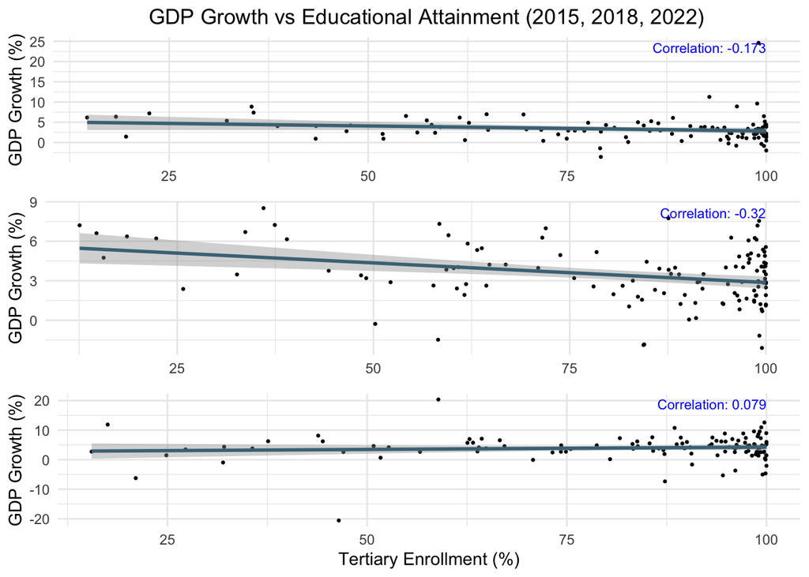

```r
library(ggplot2)
library(dplyr)
library(gridExtra)
# Filter data for years 2015, 2018, and 2022
data_2015 <- wdi_data %>% filter(year == 2015)
data_2018 <- wdi_data %>% filter(year == 2018)
data_2022 <- wdi_data %>% filter(year == 2022)
# Calculate correlations for Educational Attainment and GDP Growth
cor_2015_edu <- cor(data_2015$educational_attainment, data_2015$gdp_growth, use = "complete.obs")
cor_2018_edu <- cor(data_2018$educational_attainment, data_2018$gdp_growth, use = "complete.obs")
cor_2022_edu <- cor(data_2022$educational_attainment, data_2022$gdp_growth, use = "complete.obs")
# Scatter plot for 2015
plot_2015 <- ggplot(data_2015, aes(x = educational_attainment, y = gdp_growth)) +
  geom_point(size = 0.5, color = "black") +
  geom_smooth(method = "lm", se = TRUE, formula = y ~ x, color = "#497387") +
  annotate("text", x = max(data_2015$educational_attainment, na.rm = TRUE), y = max(data_2015$gdp_growth, na.rm = TRUE),
           label = paste0("Correlation: ", round(cor_2015_edu, 3)), hjust = 1, vjust = 1, size = 3, color = "blue") +
  labs(
    title = "GDP Growth vs Educational Attainment (2015, 2018, 2022)",
    x = NULL,
    y = "GDP Growth (%)"
  ) +
  theme_minimal() +
  theme(plot.title = element_text(hjust = 0.5))
# Scatter plot for 2018
plot_2018 <- ggplot(data_2018, aes(x = educational_attainment, y = gdp_growth)) +
  geom_point(size = 0.5, color = "black") +
  geom_smooth(method = "lm", se = TRUE, formula = y ~ x, color = "#497387") +
  annotate("text", x = max(data_2018$educational_attainment, na.rm = TRUE), y = max(data_2018$gdp_growth, na.rm = TRUE),
           label = paste0("Correlation: ", round(cor_2018_edu, 3)), hjust = 1, vjust = 1, size = 3, color = "blue") +
  labs(
    title = NULL,
    x = NULL,
    y = "GDP Growth (%)"
  ) +
  theme_minimal()
# Scatter plot for 2022
plot_2022 <- ggplot(data_2022, aes(x = educational_attainment, y = gdp_growth)) +
  geom_point(size = 0.5, color = "black") +
  geom_smooth(method = "lm", se = TRUE, formula = y ~ x, color = "#497387") +
  annotate("text", x = max(data_2022$educational_attainment, na.rm = TRUE), y = max(data_2022$gdp_growth, na.rm = TRUE),
           label = paste0("Correlation: ", round(cor_2022_edu, 3)), hjust = 1, vjust = 1, size = 3, color = "blue") +
  labs(
    title = NULL,
    x = "Tertiary Enrollment (%)",
    y = "GDP Growth (%)"
  ) +
  theme_minimal()
# Arrange the plots in a single block
grid.arrange(plot_2015, plot_2018, plot_2022, nrow = 3)
```

In 2015, a higher level of education shows a weak negative relationship with GDP growth (correlation coefficient: -0.173). The regression coefficient of -0.0082 shows that a 1% increase in education level is associated with a 0.0082% decrease in GDP growth, but this relationship is not statistically significant (p-value = 0.7129). This indicates a minimal impact of education, possibly related to the short-term economic costs of expansion. In 2018, the relationship becomes moderately negative, with a correlation coefficient of -0.3198. The regression coefficient is -0.01719, meaning that a 1% increase in education is associated with a 0.01719% decrease in GDP. However, this relationship is also not statistically significant (p-value = 0.2412), reflecting possible economic adaptations to investment in education. By 2022, the relationship between education and GDP becomes weakly positive, although it remains insignificant (correlation coefficient less than 0.5). This change may reflect the long-term economic benefits of a more highly skilled labor force in the post-pandemic period of digital transformation. Despite the positive shift, the effect of education on GDP growth in these years remains statistically insignificant. The final results indicate that education, despite its importance for long-term growth, has a limited short-term impact on GDP, which may be overridden by other dominant factors.

## 4.2 Coefficients and Summary Statistics of Linear Models 2015-2018-2022

### 4.2.1 Population Growth and GDP Growth 2015-2018-2022

```r
library(broom)
library(dplyr)
library(kableExtra)
# Fit models for each year
model_pop_2015 <- lm(gdp_growth ~ pop_growth, data = data_2015)
model_pop_2018 <- lm(gdp_growth ~ pop_growth, data = data_2018)
model_pop_2022 <- lm(gdp_growth ~ pop_growth, data = data_2022)
# Extract detailed summaries for each year
extract_full_summary <- function(model, year) {
  tidy_model <- tidy(model) %>% mutate(Year = year)
  glance_model <- glance(model) %>%
    mutate(Year = year,
           Residuals = paste("Min:", signif(min(residuals(model)), 3),
                             "1Q:", signif(quantile(residuals(model), 0.25), 3),
                             "Median:", signif(median(residuals(model)), 3),
                             "3Q:", signif(quantile(residuals(model), 0.75), 3),
                             "Max:", signif(max(residuals(model)), 3)))
  list(tidy = tidy_model, glance = glance_model)
}
summary_2015 <- extract_full_summary(model_pop_2015, 2015)
summary_2018 <- extract_full_summary(model_pop_2018, 2018)
summary_2022 <- extract_full_summary(model_pop_2022, 2022)
# Combine all data into a single data frame
all_summaries <- bind_rows(
  summary_2015$tidy,
  summary_2018$tidy,
  summary_2022$tidy
)
all_glances <- bind_rows(
  summary_2015$glance,
  summary_2018$glance,
  summary_2022$glance
)
# Create a table for coefficients
coeff_table <- all_summaries %>%
  select(Year, term, estimate, std.error, statistic, p.value) %>%
  rename(
    Term = term,
    Coefficient = estimate,
    `Std. Error` = std.error,
    `t Value` = statistic,
    `p Value` = p.value
  )
# Create a table for model statistics
stats_table <- all_glances %>%
  select(Year, Residuals, r.squared, adj.r.squared, sigma, statistic, p.value) %>%
  rename(
    `R-squared` = r.squared,
    `Adjusted R-squared` = adj.r.squared,
    `Residual Std. Error` = sigma,
    `F-statistic` = statistic,
    `Model p-value` = p.value
  )
# Combine both tables
coeff_table %>%
  kable(
    format = "html",
    digits = 3,
    caption = "Linear Model Coefficients for 2015, 2018, and 2022"
  ) %>%
  kable_styling(full_width = FALSE, bootstrap_options = c("striped", "hover", "condensed"))
```

Linear Model Coefficients for 2015, 2018, and 2022

| Year | Term | Coefficient | Std. Error | t Value | p Value |
| --- | --- | --- | --- | --- | --- |
| 2015 | (Intercept) | 2.779 | 0.391 | 7.106 | 0.000 |
| 2015 | pop_growth | 0.442 | 0.210 | 2.105 | 0.038 |
| 2018 | (Intercept) | 2.904 | 0.250 | 11.611 | 0.000 |
| 2018 | pop_growth | 0.477 | 0.154 | 3.099 | 0.002 |
| 2022 | (Intercept) | 3.420 | 0.491 | 6.965 | 0.000 |
| 2022 | pop_growth | 0.548 | 0.274 | 1.998 | 0.048 |

```r
stats_table %>%
  kable(
    format = "html",
    digits = 3,
    caption = "Linear Model Statistics for 2015, 2018, and 2022"
  ) %>%
  kable_styling(full_width = FALSE, bootstrap_options = c("striped", "hover", "condensed"))
```

Linear Model Statistics for 2015, 2018, and 2022

| Year | Residuals | R-squared | Adjusted R-squared | Residual Std. Error | F-statistic | Model p-value |
| --- | --- | --- | --- | --- | --- | --- |
| 2015 | Min: -6.67 1Q: -1.55 Median: -0.327 3Q: 1.16 Max: 21.4 | 0.040 | 0.031 | 3.096 | 4.430 | 0.038 |
| 2018 | Min: -5.35 1Q: -1.38 Median: -0.175 3Q: 1.51 Max: 4.51 | 0.074 | 0.066 | 2.074 | 9.602 | 0.002 |
| 2022 | Min: -24.8 1Q: -1.48 Median: 0.125 3Q: 1.83 Max: 16.9 | 0.034 | 0.025 | 4.356 | 3.991 | 0.048 |

Population growth has a weak positive relationship with GDP growth in all three years, as confirmed by the coefficients (2015: 0.44%, 2018: 0.48%, 2022: 0.55% GDP growth per 1% population growth) and statistical significance (p-value < 0.05). However, the low R² values (3.35%-7.35%) show that only a small part of the GDP change is explained by population growth, and the main impact is due to other factors not accounted for in the model.

The figures in the table confirm the earlier conclusions that the impact of demographic growth on economic growth is limited and requires analysis of additional variables for a full understanding.

### 4.2.2 Population Growth,GDP Growth and Income Level 2015-2018-2022

```r
library(broom)
library(dplyr)
library(kableExtra)
# Fit models with additional variable for 2015, 2018, and 2022
model_pop_2015_2 <- lm(gdp_growth ~ pop_growth + income_level, data = data_2015)
model_pop_2018_2 <- lm(gdp_growth ~ pop_growth + income_level, data = data_2018)
model_pop_2022_2 <- lm(gdp_growth ~ pop_growth + income_level, data = data_2022)
# Extract detailed summaries for each model
extract_full_summary <- function(model, year) {
  tidy_model <- tidy(model) %>% mutate(Year = year)
  glance_model <- glance(model) %>%
    mutate(Year = year,
           Residuals = paste("Min:", signif(min(residuals(model)), 3),
                             "1Q:", signif(quantile(residuals(model), 0.25), 3),
                             "Median:", signif(median(residuals(model)), 3),
                             "3Q:", signif(quantile(residuals(model), 0.75), 3),
                             "Max:", signif(max(residuals(model)), 3)))
  list(tidy = tidy_model, glance = glance_model)
}
# Extract summaries for all years
summary_2015 <- extract_full_summary(model_pop_2015_2, 2015)
summary_2018 <- extract_full_summary(model_pop_2018_2, 2018)
summary_2022 <- extract_full_summary(model_pop_2022_2, 2022)
# Combine all data into tables
all_summaries <- bind_rows(
  summary_2015$tidy,
  summary_2018$tidy,
  summary_2022$tidy
)
all_glances <- bind_rows(
  summary_2015$glance,
  summary_2018$glance,
  summary_2022$glance
)
# Create a table for coefficients
coeff_table <- all_summaries %>%
  select(Year, term, estimate, std.error, statistic, p.value) %>%
  rename(
    Term = term,
    Coefficient = estimate,
    `Std. Error` = std.error,
    `t Value` = statistic,
    `p Value` = p.value
  )
# Create a table for model statistics
stats_table <- all_glances %>%
  select(Year, Residuals, r.squared, adj.r.squared, sigma, statistic, p.value) %>%
  rename(
    `R-squared` = r.squared,
    `Adjusted R-squared` = adj.r.squared,
    `Residual Std. Error` = sigma,
    `F-statistic` = statistic,
    `Model p-value` = p.value
  )
# Display tables
coeff_table %>%
  kable(
    format = "html",
    digits = 3,
    caption = "Linear Model Coefficients with Income Level for 2015, 2018, and 2022"
  ) %>%
  kable_styling(full_width = FALSE, bootstrap_options = c("striped", "hover", "condensed"))
```

Linear Model Coefficients with Income Level for 2015, 2018, and 2022

| Year | Term | Coefficient | Std. Error | t Value | p Value |
| --- | --- | --- | --- | --- | --- |
| 2015 | (Intercept) | 2.830 | 0.501 | 5.645 | 0.000 |
| 2015 | pop_growth | 0.322 | 0.235 | 1.368 | 0.174 |
| 2015 | income_levelLow income | 0.959 | 1.216 | 0.789 | 0.432 |
| 2015 | income_levelLower middle income | 0.490 | 0.793 | 0.619 | 0.538 |
| 2015 | income_levelUpper middle income | -0.391 | 0.753 | -0.519 | 0.605 |
| 2018 | (Intercept) | 2.634 | 0.319 | 8.256 | 0.000 |
| 2018 | pop_growth | 0.274 | 0.178 | 1.540 | 0.126 |
| 2018 | income_levelLow income | 1.876 | 0.750 | 2.500 | 0.014 |
| 2018 | income_levelLower middle income | 0.668 | 0.509 | 1.313 | 0.192 |
| 2018 | income_levelUpper middle income | 0.579 | 0.450 | 1.286 | 0.201 |
| 2022 | (Intercept) | 3.269 | 0.700 | 4.667 | 0.000 |
| 2022 | pop_growth | 0.955 | 0.314 | 3.039 | 0.003 |
| 2022 | income_levelLow income | -2.038 | 1.504 | -1.355 | 0.178 |
| 2022 | income_levelLower middle income | -1.772 | 1.026 | -1.728 | 0.087 |
| 2022 | income_levelUpper middle income | 1.363 | 1.053 | 1.294 | 0.198 |

```r
stats_table %>%
  kable(
    format = "html",
    digits = 3,
    caption = "Linear Model Statistics with Income Level for 2015, 2018, and 2022"
  ) %>%
  kable_styling(full_width = FALSE, bootstrap_options = c("striped", "hover", "condensed"))
```

Linear Model Statistics with Income Level for 2015, 2018, and 2022

| Year | Residuals | R-squared | Adjusted R-squared | Residual Std. Error | F-statistic | Model p-value |
| --- | --- | --- | --- | --- | --- | --- |
| 2015 | Min: -6.24 1Q: -1.63 Median: -0.191 3Q: 1.09 Max: 21.5 | 0.053 | 0.017 | 3.119 | 1.459 | 0.220 |
| 2018 | Min: -5.49 1Q: -1.38 Median: -0.106 3Q: 1.37 Max: 4.57 | 0.125 | 0.095 | 2.042 | 4.197 | 0.003 |
| 2022 | Min: -23.4 1Q: -1.68 Median: 0.27 3Q: 2.22 Max: 15.6 | 0.095 | 0.063 | 4.271 | 2.946 | 0.023 |

Income level exhibits a varying and inconsistent relationship with GDP growth across the three years. In 2015, while the coefficients for income levels (Low: 0.959, Lower Middle: 0.490, Upper Middle: -0.391) suggest slight positive and negative associations with GDP growth, the p-values (all > 0.05) indicate that these relationships are statistically insignificant. The R-squared value of 5.3% demonstrates that only a small proportion of GDP variability is explained by the model.

In 2018, the impact of income level becomes more pronounced, with the coefficient for Low Income (1.876) being statistically significant (p-value = 0.014), indicating a meaningful positive association. However, the coefficients for other income levels remain insignificant, and the R-squared of 12.5% suggests the model captures more variability than in 2015 but still leaves a substantial portion unexplained.

By 2022, the coefficients for all income levels, including Low Income (-2.038), are statistically insignificant (all p-values > 0.05). The R-squared drops to 9.5%, further emphasizing the limited explanatory power of income level and population growth combined in this context. The low adjusted R-squared values across all years reinforce that other variables not included in the models are the primary drivers of GDP changes.

These results confirm that while income level occasionally shows a statistically significant association with GDP growth (e.g., Low Income in 2018), its overall impact is limited and inconsistent. This highlights the necessity of incorporating additional variables, such as education and age distribution, to provide a more comprehensive understanding of economic growth determinants.